# 精品案例：金融科技与传统金融岗位对比分析

狗熊会

案例难度：****

案例背景：金融业是资本与实体之间的中介，促进资本的合理配置，为实体经济的发展注入活力,随着互联网、大数据与人工智能的发展，科技的重要性被金融从业者发现。金融科技开始介入传统金融体系，成为该领域的主要参与者。与传统金融行业相比，金融科技行业在人才招聘、技术需求等有很多新的特点。

变量说明：

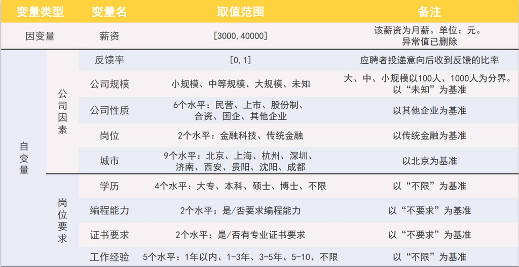

本代码仅用于狗熊会精品案例：金融科技与传统金融岗位对比分析

## 数据准备：读入数据并加载所需包

```r
# 清除工作空间
rm(list = ls())

# 加载所需要的包
library(tidyverse)
library(broom)

# 读入数据并命名为fin_data
fin_data <- read.csv("数据.csv", header = T, stringsAsFactors = FALSE)
```

### 任务一：数据处理

#### 1.1 提取薪资水平

1. 数据集中变量`X6`表示薪资区间，请提取区间中点作为薪资水平，另存为变量`wage`，对于“面议”设置为12000元，对于其他仅有上界或下界的描述（如“7000元以上”）则设置为相应界限。
2. 根据薪资水平，对原始数据进行清洗，删除月薪大于40000、低于3000的观测。

#### 1.2 岗位分类

- 下面我们要对传统金融与金融科技的岗位进行区分，数据集中`X3`为职位名称，请把名称中包含“数据”、“IT”、“量化”及“工程师”字眼的职位名称归为金融科技岗位，其他作为传统金融岗位。在数据集中增加变量`is_tech`，对于金融科技岗位`is_tech=1`，传统金融岗位`is_tech=0`。

#### 1.3 公司性质

- 从职位简介（变量`X7`）中提取公司性质信息，并命名为`company_type`，并留下“民营”、“国企”、“合资”、“股份制企业”、“上市公司五个类别”，其他类别归为“其他”。

#### 1.4 编程能力及证数要求

1. 从数据集的职位描述（变量`X8`）中查找是否存在对编程能力的要求（是否出现`"JAVA","java","Java","Python","python","matlab"`, `"MATLAB","Linux","SQL","Oracle", "Hadoop","WEB","spring","c#","C#"`, `"金融工程","编程","工程师","算法"`关键词），生成一列新的变量`coding`，需要编程能力则记为1，否则记为0。
2. 从数据集的职位描述（变量`X8`）中查找是否存在对证数的要求（是否出现`"CPA", "CFA", "FRM", "保险精算师", "注会", "证券从业", "基金从业", "法律", "司法考试", "司考"`关键词），生成一列新的变量`certificate`，需要证数水平则记为1，否则记为0。

#### 1.5 学历信息

- 从职位简介（变量`X7`）中提取学历要求信息，并命名为`degree`，并留下“本科”、“硕士”、“博士”及“大专”四个类别，其他类别归为“不限”。

#### 1.6 其他数据处理

1. 增加变量*公司规模*，命名为`company_size`，位于职位简介`X7`中，1000人以上为“大规模”；100-1000人为“中规模”；100人以下为“小规模”；其余为“未知”。
2. 增加变量*工作年限*，命名为`work`，位于职位描述`X8`中，将“无经验”和未涉及工作经验的观测统一归类到“不限”，其余类别保留。
3. 反馈率（`X2`），需转化为数值型变量并将其命名为`reply`。

### 任务二：可视化分析

#### 2.1 各城市两种岗位薪资均值对比

- 数据集中`X0`为城市名称，请按照城市名称及岗位类型（传统金融or金融科技）计算岗位的薪资水平均值，并绘制柱状图，给出解读。

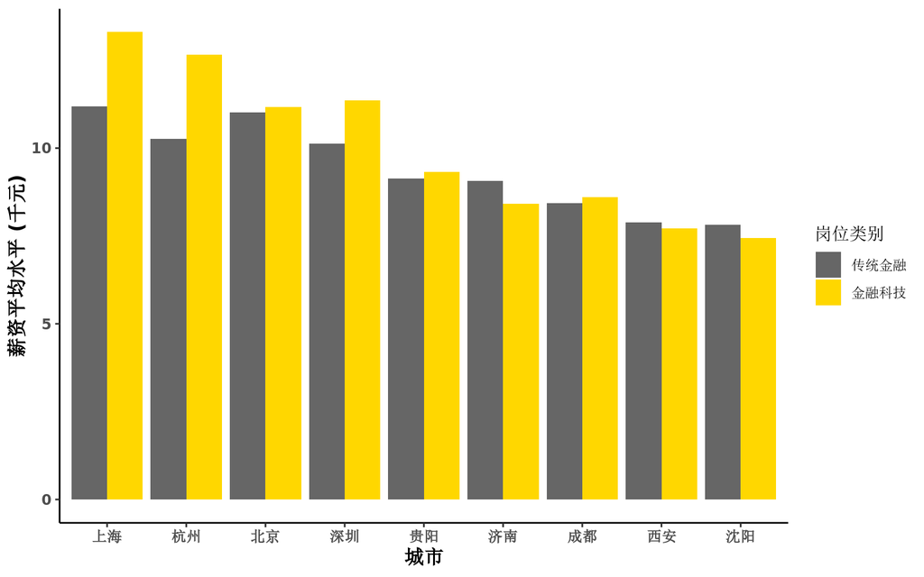

图1 各城市两种岗位薪资均值对比

#### 2.2 各城市两种岗位数目比较

- 绘制各城市两种岗位数目比较柱状图并给出解读，横轴为城市，城市按照岗位总数排列，纵轴为两类岗位个数的叠堆图，按照岗位分组

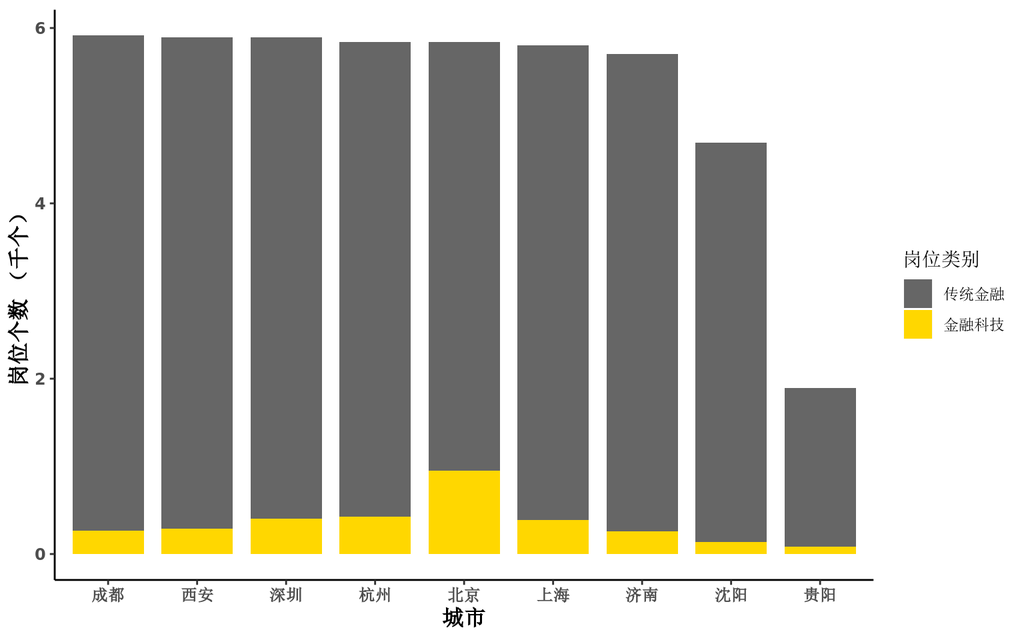

#### 2.3 绘制有编程要求和证数要求岗位所占比例

- 横轴为岗位类别，按照编程和证数要求分组；纵轴为每种要求占该岗位类别的百分比

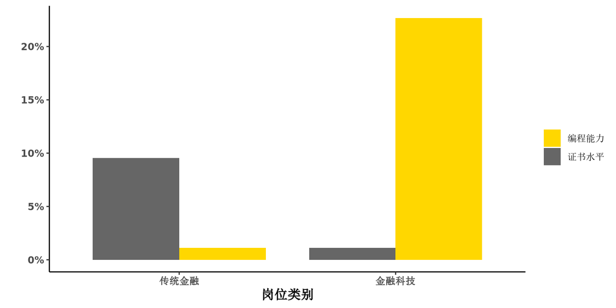

图3 不同岗位编程要求和证数要求所占比例

#### 2.4 绘制不同年限工作经验对应薪酬水平的箱线图

- 横轴为工作经验，按照岗位类别分组；纵轴为薪酬水平

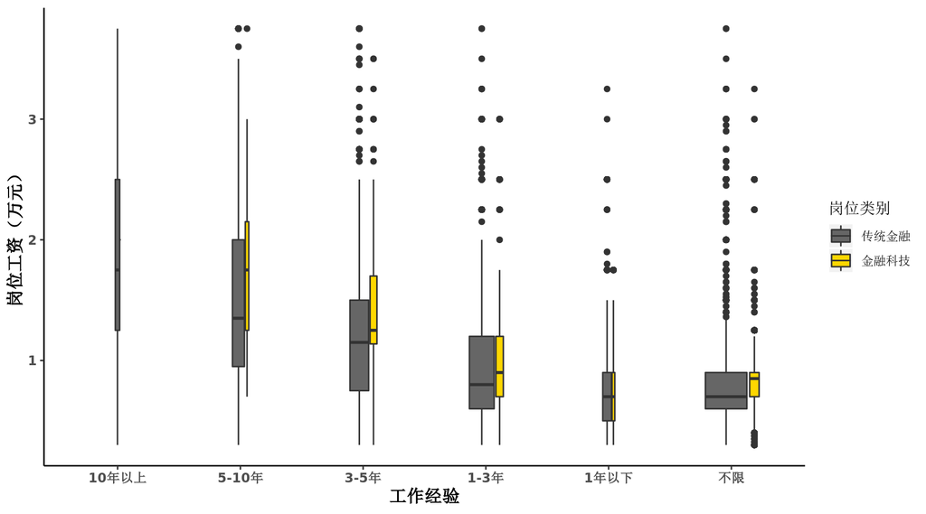

图4 不同岗位工作经验对应薪酬水品箱线图

### 任务三：建模分析

#### 3.1 回归模型、变量选择、模型诊断以及结果解读

注意，这个任务是开放型的，要求你建立回归模型，研究薪资的影响因素。利用前几个任务生成的变量进行分析，不要在这个任务再做数据处理。如果你用到了以下定性变量，请按照这个规定设置基准组。

| 变量名 | 基准组 |
| --- | --- |
| 公司规模 | 未知 |
| 公司性质 | 其他 |
| 岗位类别 | 传统金融 |
| 城市 | 北京 |
| 学历 | 不限 |
| 编程能力 | 不要求 |
| 证书要求 | 不要求 |
| 工作年限 | 不限 |

你可以尝试多种模型，包括模型选择、模型诊断等。有逻辑有条理的输出你的结果，说明你选择某一个最终模型的原因，以及对最终模型的解读。不要输出一堆中间结果给老师看。

### 任务四：聚类分析（选做）

- 此任务中我们希望对所有岗位进行聚类分析
1. 在原有变量基础上增加变量，细化编程能力和证数要求这两个变量，从数据集的职位描述（变量`X8`）中查找是否存在对编程能力（考虑下列编程语言：`"Java","Python","Matlab","C++"`, `"Linux","SQL","R","Hadoop","spring","C#"`）的要求，针对每一种语言生成一个0-1变量， 需要该项编程能力则记为1，否则记为0。在证数能力要求上，考虑CPA、CFA、FRM、SOA及司法考试这五项考试，并生成对应的0-1变量。*注 应考虑字母大小写及证数名称的中文及简写等形式*
2. 将上述用于回归分析的变量中的所有定性变量转化为one-hot encoding形式（提示 使用函数`model.matrix`），并与上面任务中的变量合并，生成用于聚类分析的矩阵，使用`kmeans`进行聚类，选择适合的类别数，并对聚类结果进行可视化，绘制分类别薪资水平密度分布图。

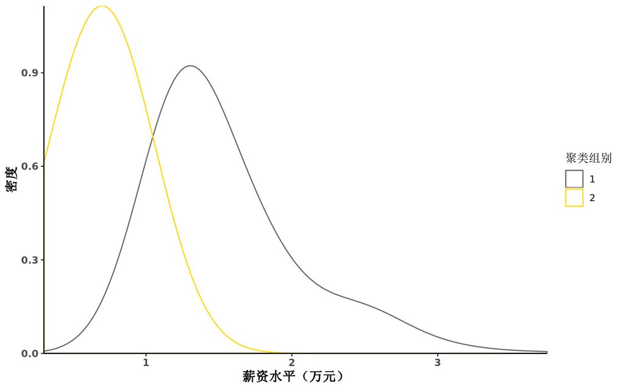

图7 聚类结果薪资水平密度图